# Google Analytics Customer Revenue Prediction

# Introdcution

A detailed analysis for Google Merchandise Store (also known as GStore, where Google swag is sold) customer dataset to predict revenue per customer. The goal is to enable marketing teams who analyze data on top of Google Analytics data to make more actionable operational changes and investment decisions.

# Loading and Exploring Data

```r
library(tidyverse)
# loading data from CSV files.
train <- read_csv("./data/input/train.csv")
```

```r
test <- read_csv("./data/input/test.csv")
```

```r
glimpse(train)
glimpse(test)
```

There are 12 features:

- **fullVisitorId** - an unique identifier for each user of the Google Merchandise Store
- **channelGrouping** - the channel via which the user came to the Store
- **date** - the date on which the user visited the Store
- **device** - the specifications for the device used to access the Store
- **geoNetwork** - this section contains information about the geography of the user
- **sessionId** - an unique identifier for this visit to the store
- **socialEngagementType** - engagement type, either “Socially Engaged” or “Not Socially Engaged”
- **totals** - this section contains aggregate values across the session
- **trafficSource** - this section contains information about the Traffic Source from which the session originated
- **visitId** - an identifier for this session
- **visitNumber** - the session number for this user
- **visitStartTime** - the timestamp (POSIX).

The columns device, geoNetwork, trafficSource, and totals are in JSON format.

# Parse JSON fields and spreed them to multiple varaiables

## Removing the identification variables

```r
library(tidyverse)
train <- train %>% select(-sessionId, -visitId)
test <- test %>% select(-sessionId, -visitId)
```

```r
setdiff(names(train), names(test))
```

```
[1] "campaignCode"       "transactionRevenue"
```

```r
train["campaignCode"] <- NULL
```

## Finding and Removing Constant Variables

```r
constant_features <- sapply(train, n_distinct)
cat("The constant features are: \n\n")
```

```
The constant features are:
```

```r
(deleted_cols = names(constant_features[constant_features == 1]))
```

```
 [1] "socialEngagementType"                "browserVersion"
 [3] "browserSize"                         "operatingSystemVersion"
 [5] "mobileDeviceBranding"                "mobileDeviceModel"
 [7] "mobileInputSelector"                 "mobileDeviceInfo"
 [9] "mobileDeviceMarketingName"           "flashVersion"
[11] "language"                            "screenColors"
[13] "screenResolution"                    "cityId"
[15] "latitude"                            "longitude"
[17] "networkLocation"                     "adwordsClickInfo.criteriaParameters"
[19] "visits"
```

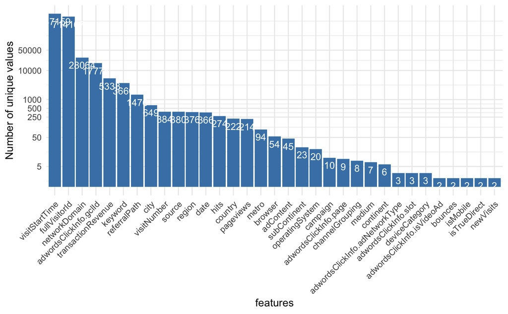

```r
train <- train %>% select(-one_of(deleted_cols))
test <- test %>% select(-one_of(deleted_cols))
rm(constant_features)
rm(deleted_cols)
train %>%
  map_dfr(n_distinct) %>%
  gather() %>%
  ggplot(aes(reorder(key, -value), value)) +
  geom_bar(stat = "identity", fill = "steelblue") +
  scale_y_log10(breaks = c(5, 50, 250, 500, 1000, 10000, 50000)) +
  geom_text(aes(label = value), vjust = 1.6, color = "white", size=3.5) +
  theme_minimal() +
  labs(x = "features", y = "Number of unique values") +
  theme(axis.text.x = element_text(angle = 45, hjust = 1))
```

## Checking features format and its content

```r
glimpse(train)
```

```
Observations: 903,653
Variables: 33
$ channelGrouping                <chr> "Organic Search", "Organic Search", "Organic Search", ...
$ date                           <int> 20160902, 20160902, 20160902, 20160902, 20160902, 2016...
$ fullVisitorId                  <chr> "1131660440785968503", "377306020877927890", "38955462...
$ visitNumber                    <int> 1, 1, 1, 1, 2, 1, 1, 1, 1, 1, 1, 1, 1, 1, 1, 1, 1, 1, ...
$ visitStartTime                 <int> 1472830385, 1472880147, 1472865386, 1472881213, 147282...
$ browser                        <chr> "Chrome", "Firefox", "Chrome", "UC Browser", "Chrome",...
$ operatingSystem                <chr> "Windows", "Macintosh", "Windows", "Linux", "Android",...
$ isMobile                       <lgl> FALSE, FALSE, FALSE, FALSE, TRUE, FALSE, FALSE, FALSE,...
$ deviceCategory                 <chr> "desktop", "desktop", "desktop", "desktop", "mobile", ...
$ continent                      <chr> "Asia", "Oceania", "Europe", "Asia", "Europe", "Europe...
$ subContinent                   <chr> "Western Asia", "Australasia", "Southern Europe", "Sou...
$ country                        <chr> "Turkey", "Australia", "Spain", "Indonesia", "United K...
$ region                         <chr> "Izmir", "not available in demo dataset", "Community o...
```

[output cut: 20 more lines]

During data observation, there is different representations for missing data. Let’s convert them to NA.

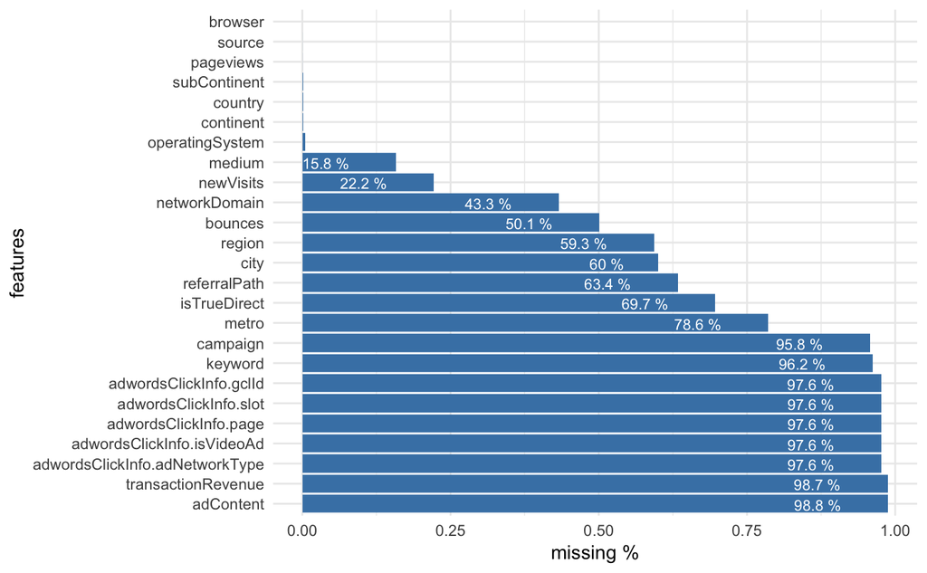

A lot of missing data in some variables!!

# Explore the target variable “transactionRevenue”

The transactionRevenue looks like it is multiplied by 10^6.

```r
y_rev <- as.numeric(train$transactionRevenue)
train$transactionRevenue <- NULL
summary(y_rev)
```

```
     Min.   1st Qu.    Median      Mean   3rd Qu.      Max.      NA's
1.000e+04 2.493e+07 4.945e+07 1.337e+08 1.077e+08 2.313e+10    892138
```

We can replce the *NA* with zero safely.

```
     Min.   1st Qu.    Median      Mean   3rd Qu.      Max.
0.000e+00 0.000e+00 0.000e+00 1.704e+06 0.000e+00 2.313e+10
```

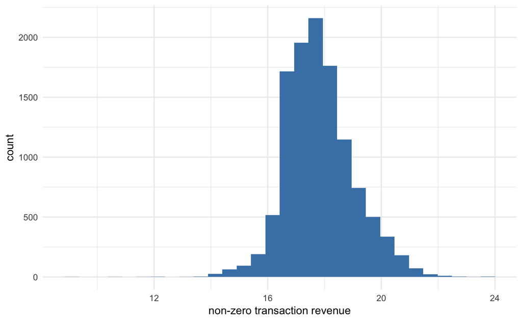

The target variable distribution is right-skewed and it multiplied by 1e6. So, log-transormation will be used.

## Revenue Vs Channel Group Relation

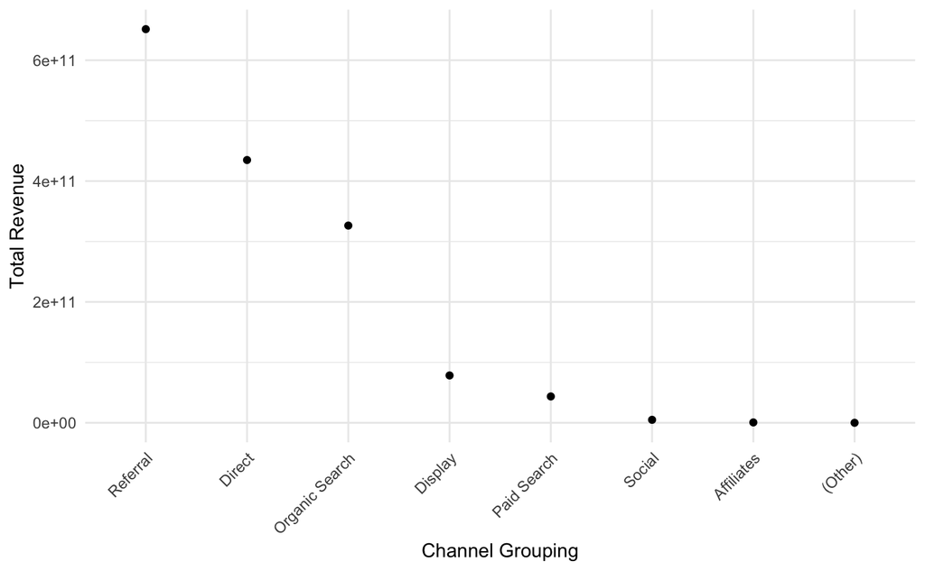

## Revenue Vs visitNumber Relation

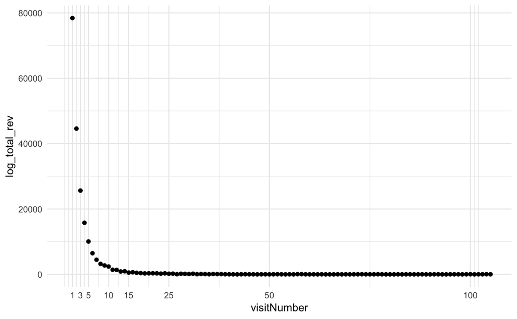

Most of the revnue comes from the first visit.

```
the standard deviation is zero
```

# Visit and Revenue Distn over multiple categorical variables

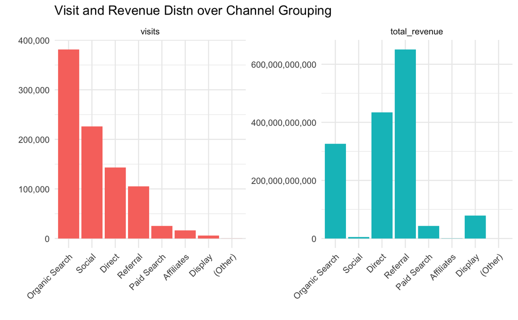

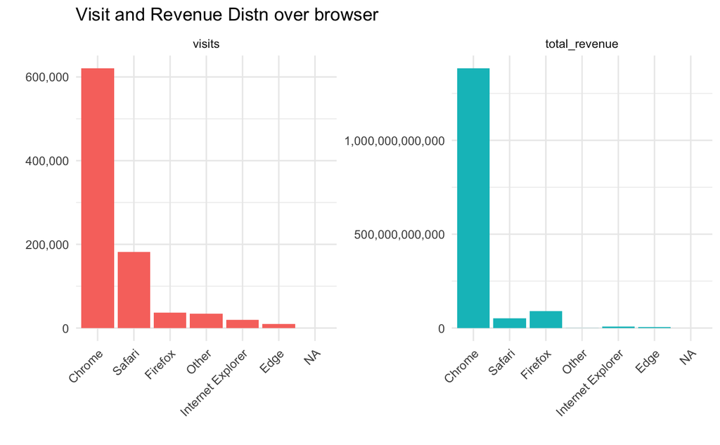

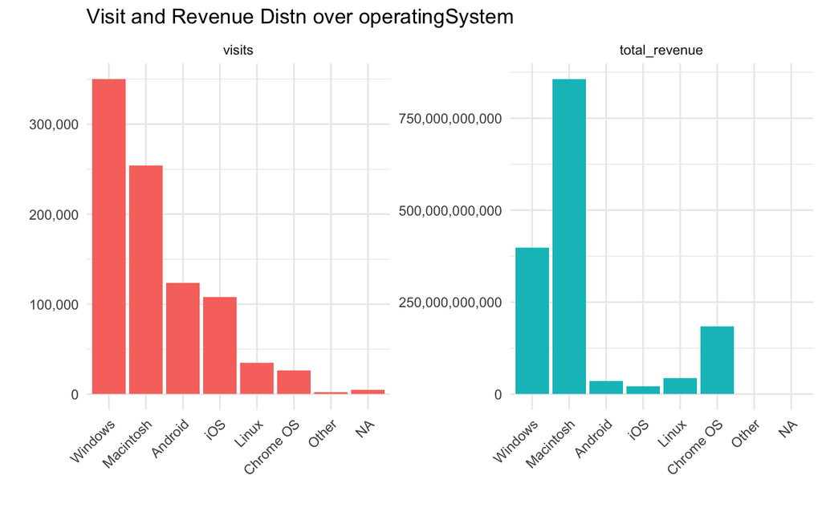

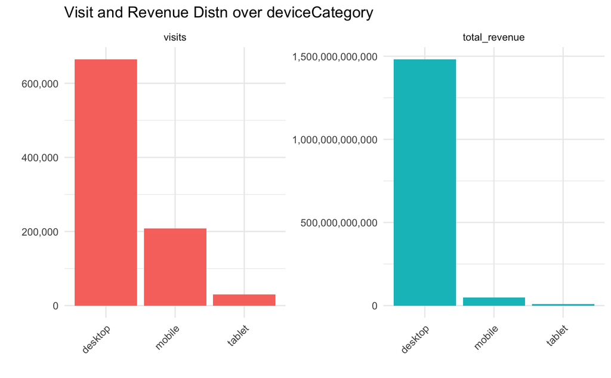

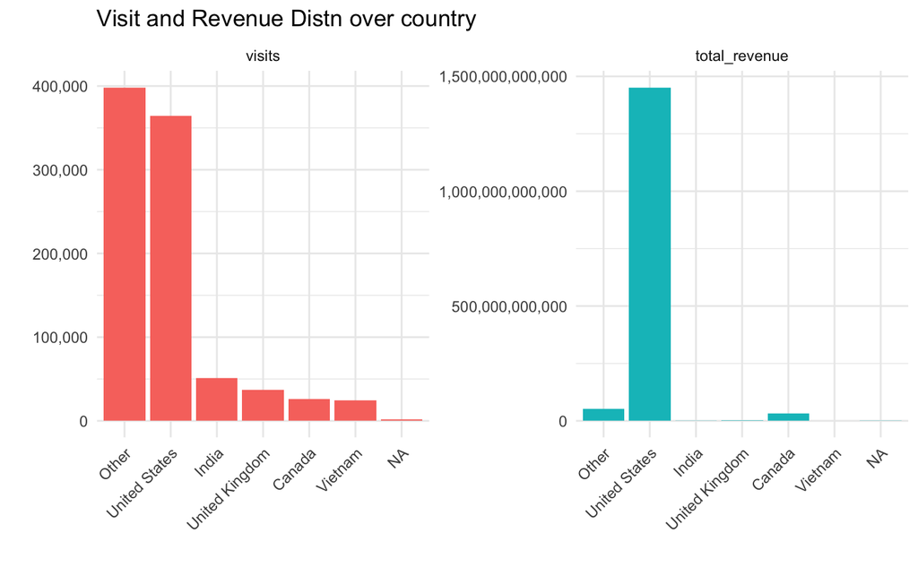

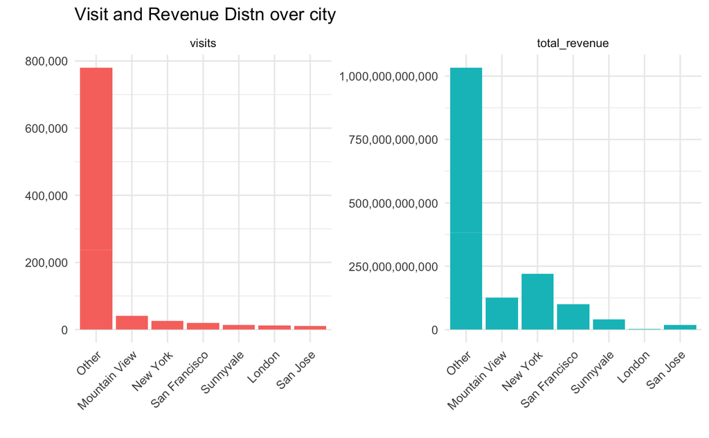

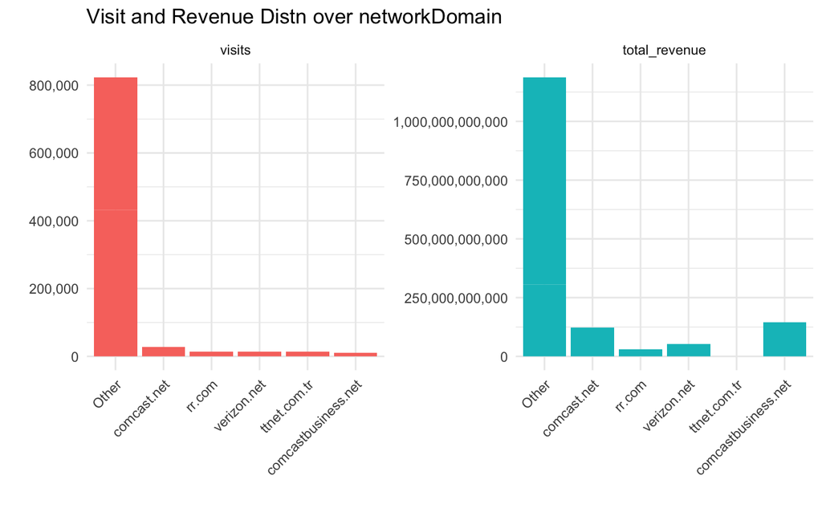

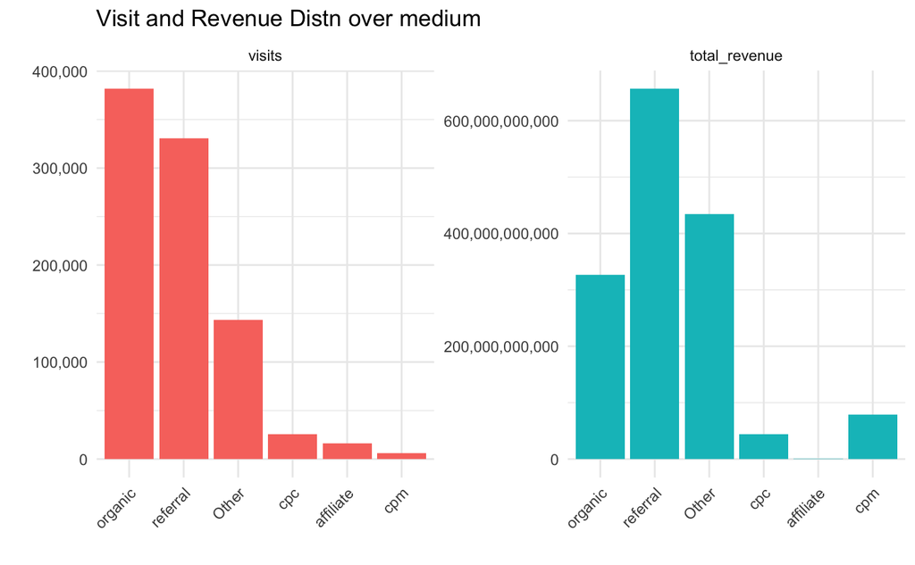

# Categorical Features Interactions

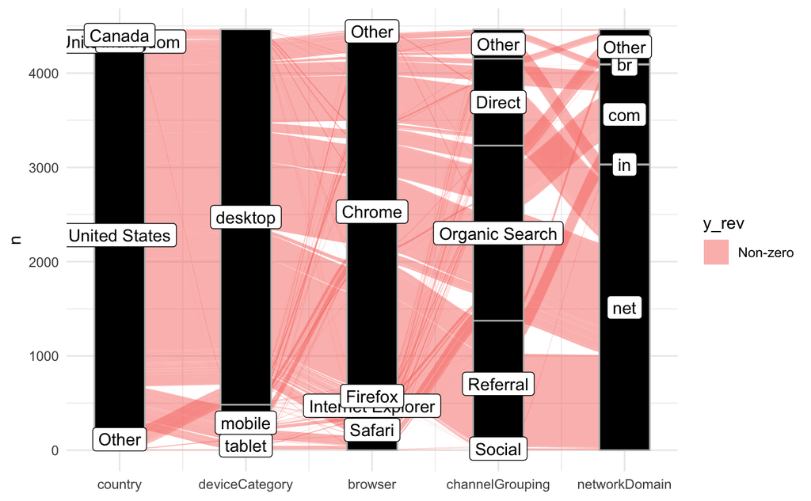

The majority of revnues comes from this interaction **US -> Desktop -> Chrome -> Referral | Organic Search -> Net**

# Data Preparation Before Training

```r
fullVisitorId <- test$fullVisitorId
id_df <- data.frame(fullVisitorId, stringsAsFactors = FALSE)
impute_missing_values <- function(df, na_level = "Missing") {
  imputed_col = data.frame(data = 1:nrow(df))
  df = as.data.frame(df)
  #loop over all variables
  for(i in 1:ncol(df)) {
    if(is.factor(df[, i])) {
      df[, i] <- fct_lump(df[, i], prop = 0.025)
      df[, i] <- fct_explicit_na(df[, i], na_level = na_level)
    }else if(is.logical(df[, i]) & sum(is.na(df[ ,i]))) {
      df[, i] = replace_na(df[, i], "Missing")
      df[, i] = factor(df[, i])
    }else if(is.numeric(df[,i]) & sum(is.na(df[ ,i]))) {
      mean_before = mean(df[, i], na.rm = TRUE)
      var = ifelse(is.na(df[, i]), 1, 0)
      imputed_col = cbind(imputed_col, as.logical(var))
      names(imputed_col)[ncol(imputed_col)] = paste(names(df)[i], "imputed", sep = "_")
      df[,i] = replace_na(df[,i], mean_before)
    }
  }
  imputed_col[1] <- NULL
  if(length(imputed_col)) {
    for(i in 1:ncol(imputed_col)) {
      df = cbind(df, imputed_col[i])
    }
  }
  return(df)
}
grp_mean <- function(x, grp) ave(x, grp, FUN = function(x) mean(x, na.rm = TRUE))
prepare_for_modeling <- function(df) {
  df %>%
  mutate(date = ymd(date),
         year = year(date) %>% factor(),
         month = year(date) %>% factor(),
         week = week(date) %>% factor(),
         day = day(date) %>% factor(),
         visit_hour = as.POSIXct(visitStartTime, origin = "1960-01-01") %>% hour %>% factor(),
         hits = as.integer(hits),
         pageviews = as.integer(pageviews),
         bounces = as.integer(bounces),
         newVisits = as.integer(newVisits),
         isMobile = ifelse(isMobile, 1L, 0L),
         isTrueDirect = ifelse(isTrueDirect, 1L, 0L),
         adwordsClickInfo.isVideoAd = ifelse(!adwordsClickInfo.isVideoAd, 0L, 1L)) %>%
  select(-date, -fullVisitorId, -visitStartTime) %>%
  mutate_if(is.character, factor) %>%
  mutate(pageviews_mean_vn = grp_mean(pageviews, visitNumber),
         hits_mean_vn = grp_mean(hits, visitNumber),
         pageviews_mean_country = grp_mean(pageviews, country),
         hits_mean_country = grp_mean(hits, country),
         pageviews_mean_city = grp_mean(pageviews, city),
         hits_mean_city = grp_mean(hits, city)) %>%
    impute_missing_values()
}
train %<>% prepare_for_modeling()
test %<>% prepare_for_modeling()
```

# Submit

A function that predicts the natural log of the sum of all transactions per user.

```r
submit <- function(pred, output_path) {

  pred <- pred %>%
    as_tibble() %>%
    set_names("y") %>%
    mutate(y = ifelse(y < 0, 0, expm1(y))) %>%
    bind_cols(id_df) %>%
    group_by(fullVisitorId) %>%
    summarise(y = log1p(sum(y)))

  read_csv("./data/input/sample_submission.csv") %>%
  left_join(pred, by = "fullVisitorId") %>%
  mutate(PredictedLogRevenue = round(y, 5)) %>%
  select(-y) %>%
  write_csv(output_path)
}
```

# Random Forest

Using ranger implementation for Random Forest algorithm.

```r
library(ranger)
rf_model = ranger(y ~ ., data = train %>% mutate(y = log1p(y_rev)))
```

```r
rf_model
summary(rf_model)
pred <- predict(rf_model, test)
submit(pred$predictions, "./data/output/ranger.csv")
```

This model scored on LB is 1.5846